# net stats play

5/9/2018

```r
if(Sys.info()['user'] %in% c('s7m', 'janus829')){
    source('~/Research/intraConfNetDyn/R/setup.R') }
pathGraphics = paste0(pathDrop, 'graphics/netStatsExplore/')
```

## net stats data

```r
# reorg to df
load(paste0(pathData, 'netStats.rda'))
netDF = do.call('rbind', netStats)
rownames(netDF) = NULL

# sep actor and graph level stats
netGraphDF = unique(netDF[,c(
    'country','year',
    names(netDF)[15:17])])
head(netGraphDF)
```

```
##     country year graph_recip graph_trans graph_dens
## 1     Sudan 1997   0.8571429   1.0000000 0.07142857
## 15    Sudan 1998   0.9356725   0.1176471 0.04385965
## 34    Sudan 1999   0.9565217   0.0000000 0.02173913
## 57    Sudan 2000   0.9733333   0.0000000 0.02000000
## 82    Sudan 2001   0.9846154   0.0000000 0.01384615
## 108   Sudan 2002   0.9867725   0.1111111 0.02248677
```

```r
netActorDF = netDF[,c(
    'country','actor','year',
    names(netDF)[1:14] )]
head(netActorDF)
```

```
##   country                               actor year inDegree outDegree
## 1   Sudan        Dinka Ethnic Militia (Sudan) 1997        0         2
## 2   Sudan          LRA: Lords Resistance Army 1997        2         0
## 3   Sudan Military Forces of Ethiopia (1991-) 1997        0         1
## 4   Sudan    Military Forces of Sudan (1989-) 1997        6         0
## 5   Sudan   Military Forces of Uganda (1986-) 1997        0         2
## 6   Sudan            Militia (Pro-Government) 1997        1         0
##   totDegree btwn     power     inClose    outClose    totClose
## 1         2    0 1.2302494 0.005494505 0.006410256 0.006410256
## 2         2    0 0.0000000 0.006410256 0.005494505 0.015625000
## 3         1    0 0.6151247 0.005494505 0.005917160 0.015384615
## 4         6    0 0.0000000 0.009615385 0.005494505 0.017857143
## 5         2    0 1.2302494 0.005494505 0.006410256 0.015873016
## 6         1    0 0.0000000 0.005917160 0.005494505 0.015151515
##      eigenCent flow gcent        icent lcent prestige
## 1 1.205994e-17    0     0 4.369881e-16     3        0
## 2 4.937862e-01    0     0 1.602290e-15     3        2
## 3 3.557435e-01    0     0 1.602290e-15     2        0
## 4 1.000000e+00    0     0 1.602290e-15     7        6
## 5 5.314048e-01    0     0 1.602290e-15     3        0
## 6 3.047424e-01    0     0 1.602290e-15     2        1
```

We calculate two sets of network statistics. Network statistics were only calculated for graphs with at least five actors.

The first set is at the graph level and includes:

- graph_recip: Compute the Reciprocity of an Input Graph or Graph Stack
- graph_trans: Compute the Transitivity of an Input Graph or Graph Stack
- graph_dens: Find the Density of a Graph

These are all stored in the `netGraphDF` object. Each of the statistics above were computed at the country-year level.

The second set of statistics is at the actor level and includes:

- inDegree: Number of incoming conflictual ties
- outDegree: Number of outgoing conflictual ties
- totDegree: inDegree + outDegree
- btwn: Vertex betweenness centrality (see `igraph` for more details)
- power: Bonacich Power Centrality Scores of Network Positions (see `igraph` for more details)
- inClose: Closeness centrality based on incoming ties (see `igraph` for more details)
- outClose: Closeness centrality based on outgoing ties (see `igraph` for more details)
- totClose: Closeness centrality based on total ties (see `igraph` for more details)
- eigenCent: Eigenvector centrality (see `igraph` for more details)
- flow: Flow Betweenness Scores of Network Positions (see `sna` for more details)
- gcent: Compute the (Harary) Graph Centrality Scores of Network Positions (see `sna` for more details)
- icent: Information Centrality Scores of Network Positions (see `sna` for more details)
- lcent: Load Centrality Scores of Network Positions (see `sna` for more details)
- prestige: Calculate the Vertex Prestige Scores (see `sna` for more details)

Each of these statistics are stored at the actor-year-country level in the `netActorDF` object.

## descriptive stats

### graph level

```r
summary(netGraphDF[,-c(1:2)])
```

```
##   graph_recip      graph_trans       graph_dens
##  Min.   :0.6000   Min.   :0.0000   Min.   :0.00000
##  1st Qu.:0.9000   1st Qu.:0.0000   1st Qu.:0.01683
##  Median :0.9524   Median :0.1268   Median :0.03571
##  Mean   :0.9288   Mean   :0.3874   Mean   :0.05742
##  3rd Qu.:0.9766   3rd Qu.:1.0000   3rd Qu.:0.07143
##  Max.   :1.0000   Max.   :1.0000   Max.   :0.40000
```

Below we show the distributions of the graph level network statistics across all country-years.

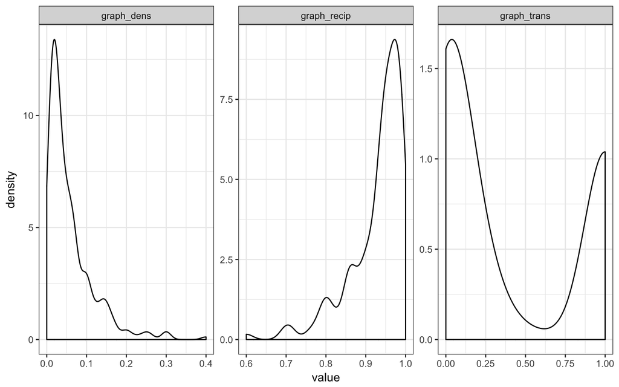

```r
ggNetGraphDF = gather(netGraphDF[,-c(1:2)])
ggplot(ggNetGraphDF, aes(x=value)) +
    geom_density() +
    facet_wrap(~key, scales='free')
```

Next we break out the results by country.

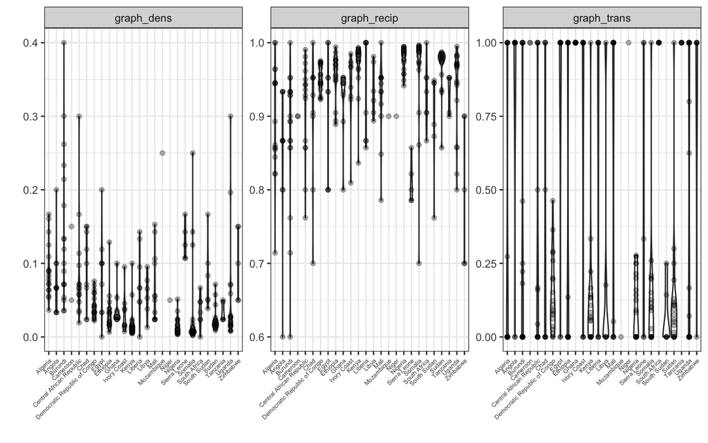

```r
ggNetGraphCntryDF = gather(netGraphDF[,-c(2)], key=key, value=value, -country)
ggplot(ggNetGraphCntryDF, aes(x=country, y=value)) +
    geom_violin() + geom_point(alpha=.3) +
    facet_wrap(~key, scales='free') +
    xlab('') + ylab('') +
    theme(
        axis.text.x = element_text(angle=45, hjust=1, size=5)
        )
```

### actor level

```r
summary(netActorDF[,-c(1:2)])
```

```
##       year         inDegree         outDegree         totDegree
##  Min.   :1997   Min.   : 0.0000   Min.   : 0.0000   Min.   : 0.000
##  1st Qu.:2004   1st Qu.: 0.0000   1st Qu.: 0.0000   1st Qu.: 0.000
##  Median :2008   Median : 0.0000   Median : 0.0000   Median : 1.000
##  Mean   :2008   Mean   : 0.6216   Mean   : 0.6216   Mean   : 1.243
##  3rd Qu.:2012   3rd Qu.: 1.0000   3rd Qu.: 1.0000   3rd Qu.: 2.000
##  Max.   :2016   Max.   :24.0000   Max.   :17.0000   Max.   :31.000
##
##       btwn              power            inClose
##  Min.   :   0.000   Min.   :-6.2869   Min.   :6.557e-05
##  1st Qu.:   0.000   1st Qu.: 0.0000   1st Qu.:4.252e-04
##  Median :   0.000   Median : 0.0000   Median :1.075e-03
##  Mean   :   3.225   Mean   :-0.0148   Mean   :6.344e-03
##  3rd Qu.:   0.000   3rd Qu.: 0.0000   3rd Qu.:4.762e-03
##  Max.   :1003.000   Max.   : 6.0315   Max.   :2.000e-01
##                     NA's   :2807
##     outClose            totClose           eigenCent
##  Min.   :6.557e-05   Min.   :6.557e-05   Min.   :0.0000
##  1st Qu.:4.252e-04   1st Qu.:4.433e-04   1st Qu.:0.0000
##  Median :1.075e-03   Median :1.189e-03   Median :0.0000
##  Mean   :6.389e-03   Mean   :7.746e-03   Mean   :0.1758
##  3rd Qu.:4.762e-03   3rd Qu.:5.249e-03   3rd Qu.:0.2466
##  Max.   :2.500e-01   Max.   :2.500e-01   Max.   :1.0000
##
##       flow              gcent              icent            lcent
##  Min.   :   0.000   Min.   :0.000000   Min.   :0.0000   Min.   :   1.0
##  1st Qu.:   0.000   1st Qu.:0.000000   1st Qu.:0.0000   1st Qu.:   1.0
##  Median :   0.000   Median :0.000000   Median :0.0000   Median :   2.0
##  Mean   :   3.454   Mean   :0.001192   Mean   :0.1969   Mean   :   8.8
##  3rd Qu.:   0.000   3rd Qu.:0.000000   3rd Qu.:0.0000   3rd Qu.:   6.0
##  Max.   :1011.000   Max.   :1.000000   Max.   :3.1791   Max.   :1077.0
##                                        NA's   :1394     NA's   :222
##     prestige
##  Min.   : 0.0000
##  1st Qu.: 0.0000
##  Median : 0.0000
##  Mean   : 0.5738
##  3rd Qu.: 1.0000
##  Max.   :23.0000
##
```

Below we show the distributions of the actor level network statistics across all actors.

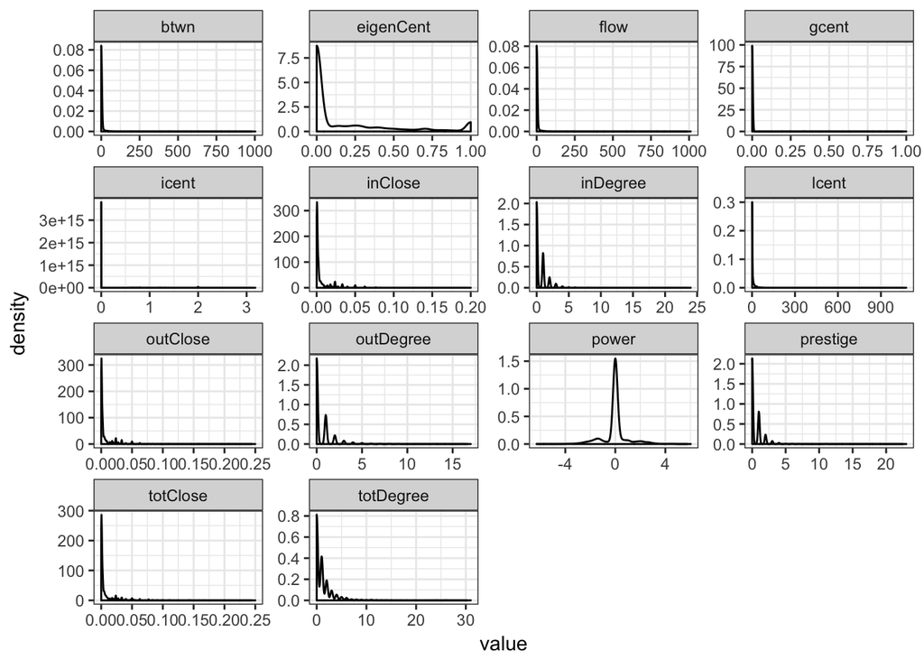

```r
ggActorGraphDF = gather(netActorDF[,-c(1:3)])
ggplot(ggActorGraphDF, aes(x=value)) +
    geom_density() +
    facet_wrap(~key, scales='free')
```

And again we break out the results by country.

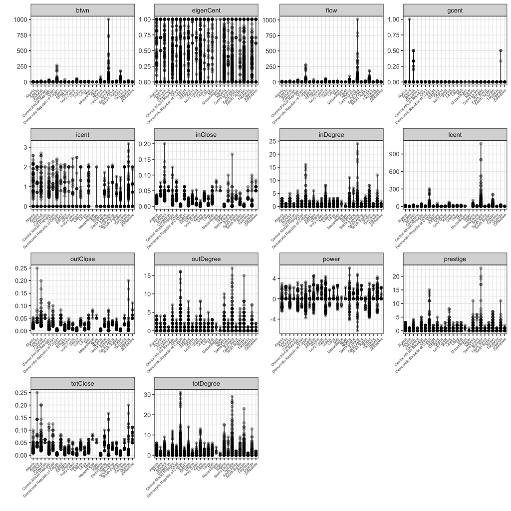

```r
ggNetActorCntryDF = gather(netActorDF[,-c(2:3)], key=key, value=value, -country)
ggplot(ggNetActorCntryDF, aes(x=country, y=value)) +
    geom_violin() + geom_point(alpha=.3) +
    facet_wrap(~key, scales='free') +
    xlab('') + ylab('') +
    theme(
        axis.text.x = element_text(angle=45, hjust=1, size=5)
        )
```